# Example evaluation of FOCUS Example Dataset D

Johannes Ranke

Last change 31 January 2019 (rebuilt 2025-02-16)

This is just a very simple vignette showing how to fit a degradation model for a parent compound with one transformation product using `mkin`. After loading the library we look at the data. We have observed concentrations in the column named `value` at the times specified in column `time` for the two observed variables named `parent` and `m1`.

```r
library(mkin, quietly = TRUE)
print(FOCUS_2006_D)
```

```
##      name time  value
## 1  parent    0  99.46
## 2  parent    0 102.04
## 3  parent    1  93.50
## 4  parent    1  92.50
## 5  parent    3  63.23
## 6  parent    3  68.99
## 7  parent    7  52.32
## 8  parent    7  55.13
## 9  parent   14  27.27
## 10 parent   14  26.64
## 11 parent   21  11.50
## 12 parent   21  11.64
## 13 parent   35   2.85
## 14 parent   35   2.91
```

[output cut: 30 more lines]

Next we specify the degradation model: The parent compound degrades with simple first-order kinetics (SFO) to one metabolite named m1, which also degrades with SFO kinetics.

The call to mkinmod returns a degradation model. The differential equations represented in R code can be found in the character vector `$diffs` of the `mkinmod` object. If a C compiler (gcc) is installed and functional, the differential equation model will be compiled from auto-generated C code.

```r
SFO_SFO <- mkinmod(parent = mkinsub("SFO", "m1"), m1 = mkinsub("SFO"))
```

```
## Successfully compiled differential equation model from auto-generated C code.
```

```r
print(SFO_SFO$diffs)
```

```
##                                                       parent
## "d_parent = - k_parent_sink * parent - k_parent_m1 * parent"
##                                                           m1
##             "d_m1 = + k_parent_m1 * parent - k_m1_sink * m1"
```

We do the fitting without progress report (`quiet = TRUE`).

```r
fit <- mkinfit(SFO_SFO, FOCUS_2006_D, quiet = TRUE)
```

A plot of the fit including a residual plot for both observed variables is obtained using the `plot_sep` method for `mkinfit` objects, which shows separate graphs for all compounds and their residuals.

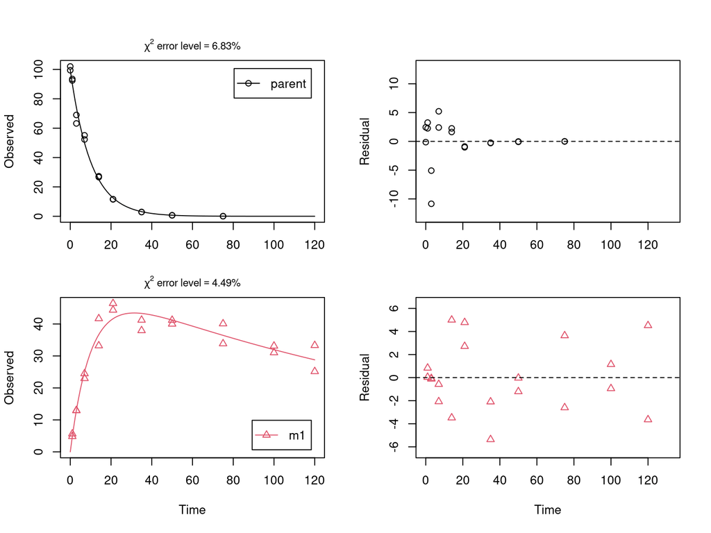

```r
plot_sep(fit, lpos = c("topright", "bottomright"))
```

Confidence intervals for the parameter estimates are obtained using the `mkinparplot` function.

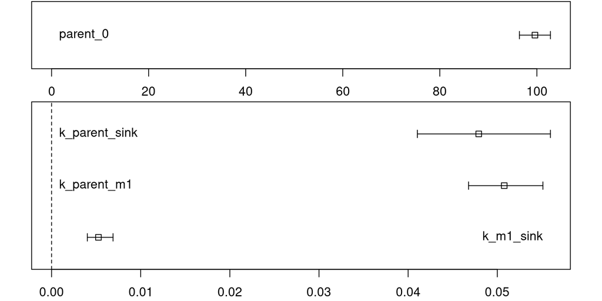

```r
mkinparplot(fit)
```

A comprehensive report of the results is obtained using the `summary` method for `mkinfit` objects.

```r
summary(fit)
```

```
## mkin version used for fitting:    0.9.49.8
## R version used for fitting:       4.4.2
## Date of fit:     Sun Feb 16 14:25:34 2025
## Date of summary: Sun Feb 16 14:25:35 2025
##
## Equations:
## d_parent/dt = - k_parent_sink * parent - k_parent_m1 * parent
## d_m1/dt = + k_parent_m1 * parent - k_m1_sink * m1
##
## Model predictions using solution type deSolve
##
## Fitted using 389 model solutions performed in 0.398 s
##
## Error model: Constant variance
##
## Error model algorithm: OLS
##
## Starting values for parameters to be optimised:
##                  value   type
## parent_0      100.7500  state
## k_parent_sink   0.1000 deparm
## k_parent_m1     0.1001 deparm
## k_m1_sink       0.1002 deparm
##
## Starting values for the transformed parameters actually optimised:
##                        value lower upper
## parent_0          100.750000  -Inf   Inf
## log_k_parent_sink  -2.302585  -Inf   Inf
## log_k_parent_m1    -2.301586  -Inf   Inf
## log_k_m1_sink      -2.300587  -Inf   Inf
##
## Fixed parameter values:
##      value  type
## m1_0     0 state
##
## Optimised, transformed parameters with symmetric confidence intervals:
##                   Estimate Std. Error  Lower   Upper
## parent_0            99.600    1.57000 96.400 102.800
## log_k_parent_sink   -3.038    0.07626 -3.193  -2.883
## log_k_parent_m1     -2.980    0.04033 -3.062  -2.898
```

[output cut: 70 more lines]

```
##     7       m1    24.47  25.04476 -5.748e-01
##    14       m1    41.69  36.69002  5.000e+00
##    14       m1    33.21  36.69002 -3.480e+00
##    21       m1    44.37  41.65310  2.717e+00
##    21       m1    46.44  41.65310  4.787e+00
##    35       m1    41.22  43.31312 -2.093e+00
##    35       m1    37.95  43.31312 -5.363e+00
##    50       m1    41.19  41.21831 -2.831e-02
##    50       m1    40.01  41.21831 -1.208e+00
##    75       m1    40.09  36.44703  3.643e+00
##    75       m1    33.85  36.44703 -2.597e+00
##   100       m1    31.04  31.98163 -9.416e-01
##   100       m1    33.13  31.98163  1.148e+00
##   120       m1    25.15  28.78984 -3.640e+00
##   120       m1    33.31  28.78984  4.520e+00
```